# RitmoStrokeWatch by FullCompression LLC

### Welcome

RitmoStrokeWatch is an apple watch workout app for on the water rowing. Monitor and record your rowing workouts for Apple healthkit or upload to Strava. It uses an automated piece timing system that replaces the need for programming workouts or having to restart a timer to capture interval training. Workout summaries contain detailed metrics for each piece of the workout.

### Data Privacy

Data is collected by RitmoStrokeWatch only while the app is active and can be shared only by direct action of the user from within the app. There is no automated data sharing to FullCompression LLC (app creator) or to any third parties.

Users can share workout data (gps locations, heart rate, stroke rate etc) with Strava by setting up authentication with their own Strava profile thru the iPhone app. Note that currently user must take action to share each workout with Strava.

Users can use the iOS sharing feature (email, text, airdrop etc) from the iPhone app to share csv or tcx format files of their workout with whomever they chose. They can also choose to collect motion data (accelerometer, gyro, raw gps) from both the watch and iPhone app and share this data in the same way.

### Quick Start

Find the icon on your apple watch and start the app. (The app will work without the iPhone with you in the boat) Press ‘Start Rowing’ just before you begin rowing. If you have an ‘always on’ display and the watch is on a wrist that feathers you should be able to see the live display of stroke rate, pace etc. The feathering motion of your wrist may not always activate the view but the app is still recording your workout. You can touch the display to re-activate the view (presumably resting between pieces) and swipe right to see summary info on the most recent piece or swipe left to see workout totals and your current heart rate. Press “Done” when the workout is completed and press “Done” again to dismiss the summary. Now following the onscreen instruction to transfer the workout file to your iphone. This part requires that the iphone be present so that the watch can be paired to it. Now open the iphone app and go to the history tab. You should see your workout. Tap on it to go to the summary view. From there you can see piece summaries (if detected), metrics at each stroke, export as csv or tcx file and upload to strava. See Strava section in help for instructions on how to sync your strava account with RitmoStrokeWatch

### App Help

Detailed help can be found in the iPhone portion of ‘RitmoStrokeWatch’. From the home page select “Go to Help”.

### Contact Us

Feel free to reach out to us at RitmoStrokeWatch@gmail.com

### MotionBeta

If the watch is placed on the oar instead of your wrist it can collect information about your rowing. The watch can be attached to the oar in the same way that it is to your wrist. Note the orientation and position of the watch face relative to the blade in the pictures. The face of the watch should be pointing to sky during the drive and facing you during the recovery. Wrist detection needs to be turned off. To do so go to the iOS watch app on the phone and select ‘passcode’ then turn off wrist detection. In the RitmoStrokeWatch app make sure the the SR Alg is set to ‘motionBeta’ this will change the stroke rate algorithm to one that requires the oar to be squared and feathered. Turn on ‘Record 100hz Motion’ before pressing start rowing. The first 50 strokes will be recorded. After that only strokes at ratings higher than the piece SR thresh will be recorded. Depending on the diameter of the oar shaft in the desired mounting area you may need some compliant material to serve as a bushing so that the watch band can be wrapped securely. The bottom 3 pictures show a piece of material that serves as a sort of bushing so that the velcro on the watch band will line up. Not all watch bands will work well. The band needs to be somewhat stretchy. The trail loop bands work well because the velcro allows exact snugness. The original hard rubber bands also work well. Bands with hook style clasps typically do NOT work well. Inexpensive bands of all kinds can be found on Amazon.

After rowing session data is recorded, simply email the motion files as attachments to RitmoStrokeWatch@gmail.com

[figure not shown]

[figure not shown]

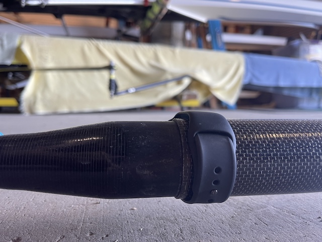

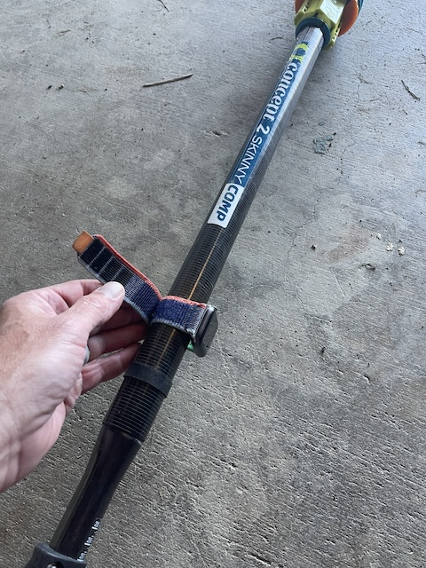

[figure not shown]

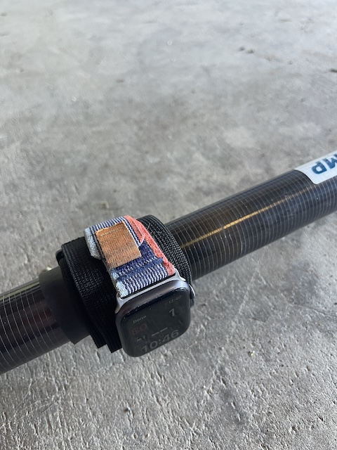